# Описание реализаций методов с примерами работы

# Методы

## CIRLS

**Прототип**

- `CIRLS(M, k, alpha=4.685, eps=1e-5, maxITER=10, maxiter=5)`

**Описание**

- Реализация комплексной версии IRLS для проекции матрицы на подпространство требуемого ранга.

**Параметры**

- `M` - траекторная матрица, которую требуется спроецировать
- `k` - ранг сигнала
- `alpha` - порог весовой функции, по умолчанию `4.685`
- `eps` - достаточная точность сходимости для остановки, по умолчанию `1e-5`
- `maxITER` - максимальное число итераций обновления матрицы весов, по умолчанию `10`
- `maxiter` - максимальное число итераций для одной матрицы весов, по умолчанию `5`

## CIRLS.mod

**Прототип**

- `CIRLS.mod(M, k, trend.ver="loess", alpha=4.046, eps=1e-7, maxITER=10, maxiter=5)`

**Описание**

- Модификация комплексной версии IRLS для проекции матрицы на подпространство требуемого ранга.

**Параметры**

- `M` - траекторная матрица, которую требуется спроецировать
- `k` - ранг сигнала
- `trend.ver` - принимает три значения: `'loess'`, `'lowess'`, `'median'`, каждое из которых соотсветсвует одноимённому методу, использующимся для поиска тренда ряда остатков, по умолчанию `'loess'`
- `alpha` - порог весовой функции, по умолчанию `4.046`
- `eps` - достаточная точность сходимости для остановки, по умолчанию `1e-7`
- `maxITER` - максимальное число итераций обновления матрицы весов, по умолчанию `10`
- `maxiter` - максимальное число итераций для одной матрицы весов, по умолчанию `5`

## l1.complex

**Прототип**

- `l1.complex(M, k, eps=1e-5, maxiter=10)`

**Описание**

- Реализация комплексной версии алгоритма для проекции матрицы на подпространство требуемого ранга по норме L1.

**Параметры**

- `M` - траекторная матрица, которую требуется спроецировать
- `k` - ранг сигнала
- `eps` - достаточная точность сходимости для остановки, по умолчанию `1e-5`
- `maxiter` - максимальное число итераций, по умолчанию `10`

# Вспомогательные функции

## weights

**Прототип**

- `weights(R,sigma,a,m,n)`

**Описание**

- Вычисление матрицы весов, используемой в методах.

**Параметры**

- `R` - матрица остатков
- `sigma` - матрица для нормировки остатков
- `a` - порог весовой функции
- `m` - число строк
- `n` - число столбцов

## calc.ends

**Прототип**

- `calc.ends(vec,L)`

**Описание**

- Вычисление скользяшей мединаны для метода `CIRLS.mod`

**Параметры**

- `vec` - вектор для вычисления
- `L` - длина окна

## weight.median

**Прототип**

- `weight.median(x, w)`

**Описание**

- Вычисления взвешенной медианы для метода `l1.complex`

**Параметры**

- `x` - веткор для вычисления
- `w` - веса

## hankL1

**Прототип**

- `hankL1(A)`

**Описание**

Диагональное усреднение для нормы в L1

**Параметры**

- `A` - матрица для усреднения

## hankL2

**Прототип**

- `hankL2(A)`

**Описание**

- Диагональное усреднение для нормы в L2

**Параметры**

- `A` - матрица для усреднения

# Пример работы методов

Подключим используемые библиотеки

```r
library(Rssa)
library(cmvnorm)

source("hank.R")
source("CIRLS_modified.R")
source("l1_complex.R")
source("CIRLS.R")
source("H_1.R")
```

Зададим ряд с шумом и выбросами

```r
N<-240
Per<-120

set.seed(7)
sig <- exp(4*(1:N)/N)*exp(2i*pi*(1:N)/30)
rnk<-1
sig.outl<-sig
outlier.seq<-sample(1:(N),N*0.01)
sig.outl[outlier.seq]<-sig.outl[outlier.seq] + 5*sig.outl[outlier.seq]

ser<-sig.outl + 0.5*exp(4*(1:N)/N)*rcnorm(N)
```

Запустим все реализованные методы на данном примере, а так же cssa, для сравнения

```r
X <- Rssa::hankel(ser, L=120)

Pr <- CIRLS(X, rnk)
Pr0 <- hankL2(Pr)

Pr <- l1.complex(X, rnk)
Pr.L1 <- hankL1(Pr)

Pr <- CIRLS.mod(X,rnk,'loess') #CIRLS modification (trend extraction with loess)
Pr1 <- hankL2(Pr)

Pr <- CIRLS.mod(X,rnk,'median') #CIRLS modification (trend extraction with median)
Pr2 <- hankL2(Pr)

Pr <- CIRLS.mod(X,rnk,'lowess') #CIRLS modification (trend extraction with lowess)
Pr3 <- hankL2(Pr)

s <- ssa(ser, kind = "cssa")
r <- reconstruct(s, groups = list(Trend = 1:rnk))
```

Отразим результаты работы методов на графике.

Вещественная часть

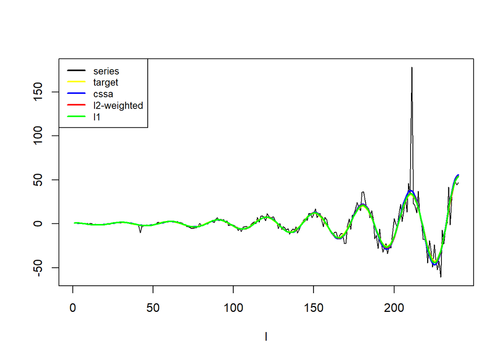

```r
plot(Re(ser),col='black',type='l', xlab = "l", ylab = "")
lines( Re(sig), type='l', col='yellow', lw=2)
lines( Re(r$Trend),type='l',col='blue',lw=2)
lines( Re(Pr0),type='l',col='red',lw=2)
lines( Re(Pr.L1), type='l', col='green', lw=2)
legend('topleft', c("series", "target", "cssa", "l2-weighted", "l1"),
       col=c("black", "yellow", "blue", "red", "green"), lty=1, cex=0.8, lw=c(2, 2, 2, 2, 2))
```

Мнимая часть

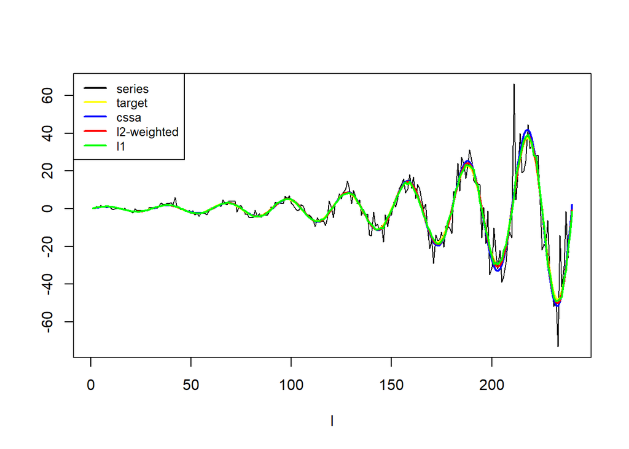

```r
plot(Im(ser),col='black',type='l', xlab = "l", ylab = "")
lines( Im(sig), type='l', col='yellow', lw=2)
lines( Im(r$Trend),type='l',col='blue',lw=2)
lines( Im(Pr0),type='l',col='red',lw=2)
lines( Im(Pr.L1), type='l', col='green', lw=2)
legend('topleft', c("series", "target", "cssa", "l2-weighted", "l1"),
       col=c("black", "yellow", "blue", "red", "green"), lty=1, cex=0.8, lw=c(2, 2, 2, 2, 2))
```

# Первый порядок ошибки

## H.1

**Прототип**

- `H.1(E, U, V)`

# Пример нахождения первого порядка ошибки.

Генерация сигнала и шума, задание длины ряда и длины окна.

```r
sig.n <- function(N) {
  cos(2 * pi * (1:N) / 10) +  1i * cos(2 * pi * (1:N) / 10 + pi/4)
}

noise.n <- function(N) {
  0.1 * (rnorm(N, sd = 1) + 1i * rnorm(N, sd = 1))
}

N <- 9 #series length
L <- 5 #window length

sig <- sig.n(N)

set.seed(6)
noise <- noise.n(N)
```

Найдём сигнулярные вектора для траекторной матрицы сигнала при помощи пакета Rssa

```r
s <- ssa(sig, L = L, kind = "cssa", svd.method = "svd")

rec <- reconstruct(s, groups = list(1:2))[[1]]
U <- list(s$U[,1] + 1i * 0, s$U[,2] + 1i * 0)
V <- list(s$V[,1] + 1i * 0, s$V[,2] + 1i * 0)
```

Теперь достаточно найти таректорную матрицу шума и можно найти первый порядок ошибки

```r
E <- Rssa::hankel(noise, L)
H <- H.1(E, U, V)
#first order error
err.1 <- hankL2(H)
```

Найдём полную ошибку

```r
s <- ssa(sig + noise, L = L, kind = "cssa", svd.method = "svd")
rec <- reconstruct(s, groups = list(1:2))[[1]]
#full error
err <- rec - sig
```

Сравним полученное на графике

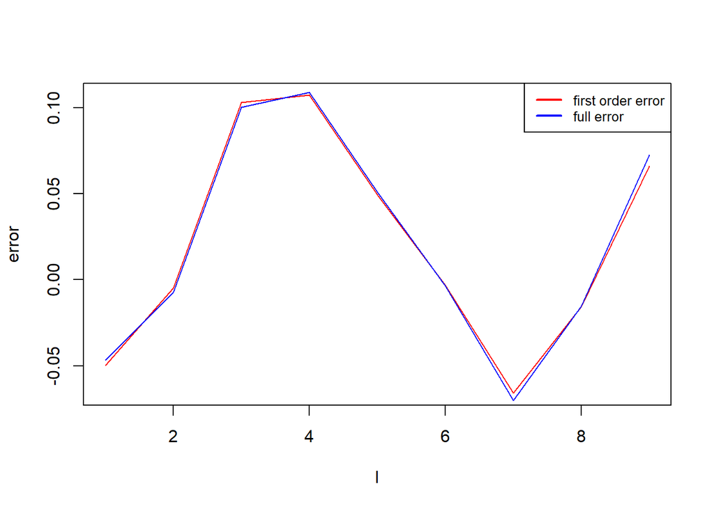

```r
plot(Re(err.1), type='l', col = "red", xlab = "l", ylab = "error")
lines(Re(err), type = 'l', col = "blue")
legend('topright', c("first order error", "full error"),
       col=c("red", "blue"), lty=1, cex=0.8, lw=c(2, 2))
```